# Homework

Yufeng Cheng

2025-12-14

# HW1

## Question

3.4 写一个能生成Rayleigh分布随机数的算法并生成对应样本，验证样本的众数接近理论众数。

3.5 使用逆变换法生成离散随机变量X的样本，样本量为1000，并比较经验概率和理论概率，X的分布如下表：

| x | 0 | 1 | 2 | 3 | 4 |
| --- | --- | --- | --- | --- | --- |
| p(x) | 0.1 | 0.2 | 0.2 | 0.2 | 0.3 |

3.7 写一个使用接受拒绝法生成Beta(a,b)分布的随机数的算法并生成一个样本量为1000、服从Beta(3,2)的样本。画出其直方图并叠加理论样本。

3.11 生成来自混合正态分布$p_1N(0,1)+(1-p_1)N(3,1)$的样本，样本量为1000。画出$p_1=0.5$以及其他值时的直方图，推测能出现双峰分布的值。

3.12 模拟指数-伽马混合变量。$\Lambda \sim Gamma(r,\beta)$，$Y|\Lambda \sim Exp(\Lambda)$。样本量为1000，$r=4$，$\beta=2$。

## Answer

### 3.4

利用逆变换法生成Rayleigh分布随机数。其累积分布函数为
$$F(x)=1-e^{-\frac{x^2}{2\sigma^2}},\quad x\geq 0,\sigma >0.$$

生成均匀分布随机数$Y\sim U(0,1)$并令$X=F^{-1}(Y)=\sqrt{-2\sigma^2 \log{1-Y}}\sim Rayleigh(\sigma)$。

代码如下：

```r
set.seed(0)
rRayleigh <- function(n, sigma){
  y <- runif(n)
  x <- sqrt(-2*sigma^2*log(1-y))
  x
}
```

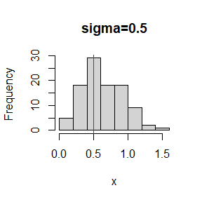

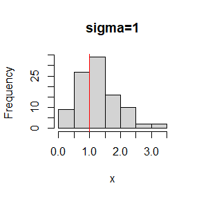

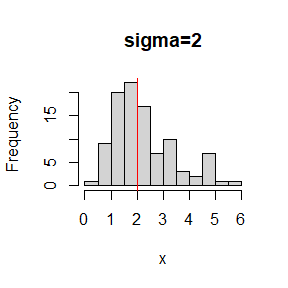

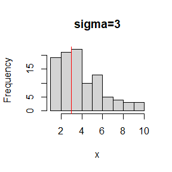

### 3.5

先用逆变换法生成对应样本

```r
n <- 1000
y <- runif(n)
p <- c(.1,.2,.2,.2,.3)
cp <- cumsum(p)
x <- findInterval(y, cp)
```

比较经验概率和理论概率

```r
phat <- as.vector(table(x)/n)
data.frame(phat,p)
```

```
##    phat   p
## 1 0.114 0.1
## 2 0.190 0.2
## 3 0.213 0.2
## 4 0.177 0.2
## 5 0.306 0.3
```

可以看到经验概率接近理论概率。

### 3.7

Beta(a,b)的概率密度函数为
$$f(x;a,b)=\frac{x^{a-1}(1-x)^{b-1}}{B(a,b)}, \quad 0\leq x \leq 1$$
其中B(a,b)为beta函数。

令$g(x)=I_{[0,1]}(x)$，则当$0<x<1$且$a,b>1$时，有
$$\frac{f(x;a,b)}{g(x)}\leq
\frac{(a-1)^{a-1}(b-1)^{b-1}}{B(a,b)(a+b-2)^{a+b-2}}.$$

当$0<x<1$且$0<a,b\leq 1$时，有
$$\frac{f(x;a,b)}{g(x)}\leq \frac{1}{B(a,b)}.$$

具体算法如下

```r
rbeta2 <- function(n, a, b){
  if(a>1 && b>1){
    c <- (a-1)^(a-1)*(b-1)^(b-1)/beta(a,b)/(a+b-2)^(a+b-2)
  } else{
    c <- 1
  }
  y <- runif(n*(c+0.1))
  r <- runif(length(y))
  x <- y[r<dbeta(y,a,b)/c]
  if(length(x)>=n){
    return(x[1:n])
  } else{
    return(c(x, rbeta2(n-length(x), a, b)))
  }
}
```

生成样本量为1000的Beta(3,2)分布。

```r
x <- rbeta2(1000,3,2)
```

画出直方图并叠加理论密度函数

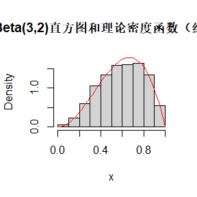

```r
x_seq <- seq(0,1,0.02)
y_seq <- sapply(x_seq, function(x) dbeta(x,3,2))


hist(x, freq = F, ylim = c(0,1.8),
     main = "Beta(3,2)直方图和理论密度函数（红色）")
lines(x_seq,y_seq,col="red")
```

### 3.11

下为随机数算法

```r
rmixnorm <- function(n,p){
  x1 <- rnorm(n,0,1)
  x2 <- rnorm(n,3,1)
  r <- sample(0:1,n, replace = T, prob = c(1-p,p))
  return(r*x1+(1-r)*x2)
}
```

$p_1=0.5$时结果如下

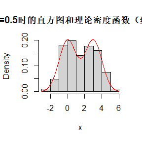

```r
x_seq <- seq(-3,6,0.02)
y_seq <- sapply(x_seq,
                function(x) (dnorm(x,0,1)+dnorm(x,3,1))/2)

n <- 1000
x <- rmixnorm(n,p=0.5)
hist(x, freq = F,
     main = "p=0.5时的直方图和理论密度函数（红色）")
lines(x_seq,y_seq,col="red")
```

对不同的p进行重复

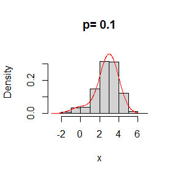

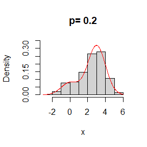

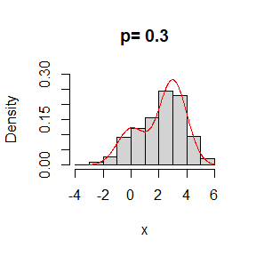

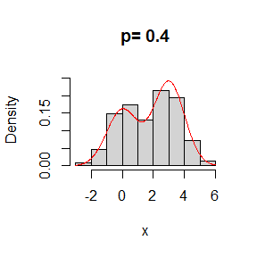

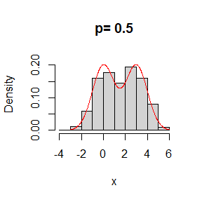

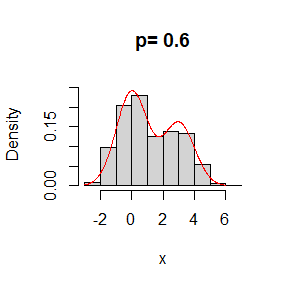

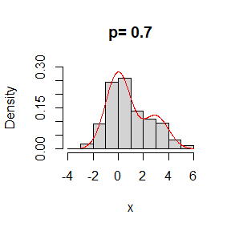

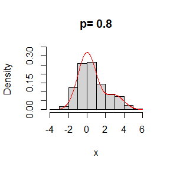

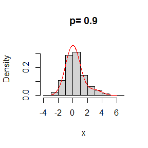

观察图像可以看出，$0.4\leq p \leq 0.6$时会出现较为明显的双峰。

### 3.12

代码如下

```r
n <- 1000
Gam <- rgamma(n, 4, 2)
y <- rexp(n, Gam)
```

# HW2

## Question

6.4 用蒙特卡洛方法估计beta(3,3)的cdf，计算$x=0.1,0.2,\dots,0.9$处的值并与pbeta的结果相比较。

6.6 对于蒙特卡洛积分
$$\theta=\int_0^1 e^xdx,$$
考虑对偶变量法，计算$Cov(e^U,e^{1-U})$和$Var(e^U+e^{1-U})$，其中$U\sim U(0,1)$以及方差缩减的百分比。

6.14 找到两个重要函数以用重要抽样法估计积分
$$\int_1^{+\infty} \frac{x^2}{\sqrt{2\pi}}e^{-\frac{x^2}{2}},$$
判断谁的方差更小并解释之。

Monte Carlo experiment 对于$n=1\times 10^4,2\times 10^4,4\times 10^4,6\times 10^4,8\times 10^4$，利用benchmark函数比较快速排序n个随机数的用时，记作$t_n$。然后对$t_n$与$a_n=nlogn$拟合线性模型并绘图表示。

## Answer

### 6.4

用蒙特卡洛方法估计beta(3,3)的cdf。

```r
set.seed(0)
pbeta1 <- function(n,a,b,x){
  r <- rbeta(n,a,b)
  phat <- sapply(x, function(k) sum(r<k)/n)
  return(phat)
}
```

与pbeta的结果相比较。

```r
p1 <- pbeta1(10000,3,3,(1:9)/10)
p2 <- pbeta((1:9)/10,3,3)
p1 %>% round(.,4)# 蒙特卡洛的结果
```

```
## [1] 0.0078 0.0598 0.1669 0.3153 0.4973 0.6749 0.8374 0.9407 0.9913
```

```r
p2 %>% round(.,4)# pbeta的结果
```

```
## [1] 0.0086 0.0579 0.1631 0.3174 0.5000 0.6826 0.8369 0.9421 0.9914
```

```r
round(abs(p1-p2)/p2,4) # 蒙特卡洛估计的相对偏差
```

```
## [1] 0.0888 0.0325 0.0234 0.0067 0.0054 0.0112 0.0006 0.0015 0.0001
```

可以看到，二者结果相差不大，且随着x的增大，样本点随之增多，蒙特卡洛估计的相对偏差也逐渐减小。

### 6.6

$$\begin{aligned}
&\begin{aligned}
Cov(e^U,e^{1-U})
&=E[e^Ue^{1-U}]-E[e^U]E[e^{1-U}] \\
&=e-(1-e)^2
\end{aligned} \\
&\begin{aligned}
Var(e^U+e^{1-U})
&=Var(e^U)+Var(e^{1-U})+2Cov(e^U,e^{1-U}) \\
&=-3e^2+10e-5
\end{aligned} \\
\end{aligned}$$

记$\hat{\theta}_{av}$和$\hat{\theta}_{MC}$分别为使用对偶变量法和普通蒙特卡洛法对$\theta$的估计，则
$$\begin{aligned}
&\begin{aligned}
Var(\hat{\theta}_{av})
&=\frac{Var(\frac{e^U+e^{1-U}}{2})}{n/2} \\
&=\frac{1}{2n}(-3e^2+10e-5)
\end{aligned} \\
&\begin{aligned}
Var(\hat{\theta}_{MC})
&=\frac{Var(e^U)}{n} \\
&=\frac{1}{2n}(-e^2+4e-3)
\end{aligned} \\
&\begin{aligned}
\frac{Var(\hat{\theta}_{MC})-Var(\hat{\theta}_{av})}{Var(\hat{\theta}_{MC})}
&\approx 96.8\%
\end{aligned} \\
\end{aligned}$$

### 6.14

两个重要函数分别为$f_1(x)=\sqrt{e}xe^{-\frac{x^2}{2}}I(x\geq 1)$和$f_2(x)=\frac{1}{\sqrt{2\pi}(1-\Phi(1))}e^{-\frac{x^2}{2}}I(x\geq 1)$，其中$\Phi(\cdot)$为标准正态分布的累积分布函数。利用蒙特卡洛法比较两个估计的方差大小。

```r
n <- 1000

hat1 <- replicate(100, expr = {
  x <- runif(n)
  y <- sqrt(1-2*log(x))
  mean(y/sqrt(2*pi*exp(1)))
})

hat2 <- replicate(100, expr = {
    x <- rnorm(n*10)
    x <- x[x>=1][1:n]
    mean(x^2*(1-pnorm(1)))
})

c(mean(hat1),mean(hat2))
```

```
## [1] 0.4007863 0.4022691
```

```r
c(sd(hat1),sd(hat2))
```

```
## [1] 0.003369798 0.008538374
```

可以看到由第一个重要函数得到的估计方差更小。这是因为对积分起到主要贡献的为$x\in[1,4]$这一部分，而在这一区域上$f_1(x)$比起$f_2(x)$更接近$g(x)$，因此方差更小。

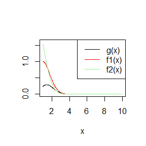

```r
x <- seq(1,10,0.02)
y1 <- sapply(x, function(x){
  x^2/sqrt(2*pi)*exp(-x^2/2)
})
y2 <- sapply(x, function(x){
  x*exp(-x^2/2+1/2)
})
y3 <- sapply(x, function(x){
  1/sqrt(2*pi)*exp(-x^2/2)/(1-pnorm(1))
})

plot(x,y1,ylim = c(0,1.6), type = "l",ylab="")
lines(x,y2,col="red")
lines(x,y3,col="lightgreen")
legend("topright", legend = c("g(x)","f1(x)","f2(x)"),
       col = c("black","red","lightgreen"),lty = rep(1,3))
```

### Monte Carlo experiment

计算$t_n$。

```r
x <- c(1,2,4,6,8)*1e4
t <- benchmark(replications = 1000,
          sort(sample(1:x[1],x[1])),
          sort(sample(1:x[2],x[2])),
          sort(sample(1:x[3],x[3])),
          sort(sample(1:x[4],x[4])),
          sort(sample(1:x[5],x[5])),
          columns = c("user.self"))
tn <- t$user.self
```

拟合线性模型并绘图表示。

```r
an <- x*log(x)
fit <- lm(tn~an)
summary(fit)
```

```
##
## Call:
## lm(formula = tn ~ an)
##
## Residuals:
##        1        2        3        4        5
##  0.01229 -0.01347  0.02884 -0.05879  0.03114
##
## Coefficients:
##              Estimate Std. Error t value Pr(>|t|)
## (Intercept) 7.812e-02  3.533e-02   2.211    0.114
## an          4.773e-06  6.496e-08  73.475 5.56e-06 ***
## ---
## Signif. codes:  0 '***' 0.001 '**' 0.01 '*' 0.05 '.' 0.1 ' ' 1
##
## Residual standard error: 0.04317 on 3 degrees of freedom
## Multiple R-squared:  0.9994, Adjusted R-squared:  0.9993
## F-statistic:  5399 on 1 and 3 DF,  p-value: 5.556e-06
```

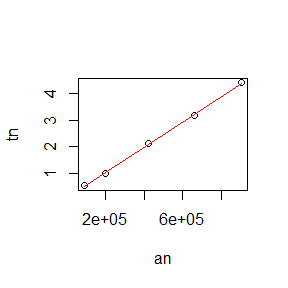

```r
plot(an,tn)
lines(an,fit$fitted.values,col="red")
```

# HW3

## Question

6.15 用分层重要抽样法计算
$$\int_0^1 \frac{e^x}{1+x^2}dx,$$
将区间(0,1)分为5层$((j-1)/5,j/5,\quad j=1,2,\cdots,5$。第j层的重要函数取为
$$\frac{5e^{-x}}{1-e^{-1}},\quad \frac{j-1}{5}<x<\frac{j}{5}。$$
并把结果与例6.11相比较。

7.3 仿照例7.9，绘制样本量为$n=10,20,30,40,50$时t检验的功效曲线并分析功效与样本量之间的关系。

7.6 用蒙特卡洛实验估计非正态情况下$95\%$对称t区间估计均值时的覆盖率，其中真实分布为$\chi^2(2)$，样本量为20。将结果与例7.4相比较。

7.A 使用蒙特卡洛模拟研究当抽样总体不服从正态分布时，t检验的经验第一类错误率是否大致等于名义显著性水平$\alpha$。真实分布分别取为$\chi^2(1)$，$U(0,2)$和$Exp(1)$。

## Answer

### 6.15

```r
set.seed(0)
m <- 10000
k <- 5
g <- function(x) {
exp(-x- log(1+x^2)) * (x > 0) * (x < 1)
}
F_inv <- function(x){ # 逆变换法
  -log(1-(1-exp(-1))*x)
}
rf <- function(n,a0,a1){
    u <- runif(n)
    x <- -log(exp(-a0)-(exp(-a0)-exp(-a1))*u)
    x
}
fg <- function(x){ # g/f
  g(x)*exp(x)*(1-exp(-1))
}

j <- seq(0,1,length.out=k+1) %>% F_inv
test <- function(){mean(sapply(1:k,FUN = function(i){
    x <- rf(m,j[i],j[i+1])
    mean(fg(x))
}))}



sfInit(parallel = T,cpus = 8)
```

```
## R Version:  R version 4.4.2 (2024-10-31 ucrt)
```

```
## snowfall 1.84-6.3 initialized (using snow 0.4-4): parallel execution on 8 CPUs.
```

```r
sfExport("j","k","m","g","fg","F_inv","rf","test")
result <- sfSapply(1:1000,fun = function(k) test())
sfStop()
```

```
##
## Stopping cluster
```

```r
mean(result)
```

```
## [1] 0.5247965
```

```r
sd(result)
```

```
## [1] 9.269247e-05
```

同样的样本量下，分层重要抽样法的估计标准差为`9.27\times 10^{-5}`，远小于一般重要抽样法的估计标准差0.0970314，因此分层重要抽样法的估计值$\hat{\theta}^{SI}=$`0.5247965`也比一般重要抽样法的估计值$\hat{\theta}^{S}=0.5257801$更精确。

### 7.3

```r
n <- 1:5 *10
m <- 1000
mu0 <- 500
mu <- c(seq(450, 650, 10))
sigma <- 100

powers <- sapply(n, FUN = function(n){
  sapply(mu, FUN = function(mu){
    pvalues <- replicate(m, expr = {
    x <- rnorm(n, mean = mu, sd = sigma)
    ttest <- t.test(x,
    alternative = "greater", mu = mu0)
    ttest$p.value } )
    mean(pvalues <= .05)
  })
})
```

下图为不同样本量功效曲线，图中黑色竖线为参数真值$\mu_0=500$，黑色横线为$p=0.05$。

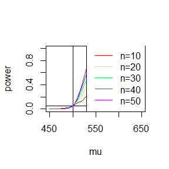

```r
plot(mu,powers[,1], type="l",col=rainbow(5)[1],ylab = "power")
abline(v=500,h=0.05)
for(i in 2:5){
  lines(mu,powers[,i],col=rainbow(5)[i])
}
legend("bottomright",
       legend = c("n=10","n=20","n=30","n=40","n=50"),
       col = rainbow(5),lty=rep(1,5))
```

从图中可以看出，$\mu>\mu_0=500$时，随着样本量的增加，拒绝原假设的概率也随之增大；当$\mu=\mu_0=500$时，不同样本量都近似满足$\alpha=0.05$的第一类错误率水平；当$\mu<\mu_0=500$时，随着样本量的增加，拒绝原假设的概率随之减小。

### 7.6

置信水平$95\%$的对称t区间为
$$[\bar{X}-\frac{S}{\sqrt{n}}t_{n-1}(0.975),\bar{X}+\frac{S}{\sqrt{n}}t_{n-1}(0.975)]。$$

```r
cover1 <- function(x,mu0,alpha=0.05){# 判断均值是否落在置信区间内
  n <- length(x)
  return((mu0>mean(x)-qt(1-alpha/2,n-1)*sd(x)/sqrt(n))*
           (mu0<mean(x)+qt(1-alpha/2,n-1)*sd(x)/sqrt(n)))
}
cover2 <- function(x,sigma2,alpha=0.05){# 判断方差是否落在置信区间内
  n <- length(x)
  S <- (n-1) * var(x) / qchisq(alpha, df = n-1)
  return(sigma2<S)
}

test <- replicate(50000,expr = {
  x <- rchisq(20,2)
  c(cover1(x,2),cover2(x,4))
})

rowMeans(test)
```

```
## [1] 0.91918 0.78204
```

均值的覆盖率为`0.91918`，方差的覆盖率为`0.78204`。前者更接近名义覆盖率$95\%$，这也反映出了均值的t区间估计比方差的区间估计更为稳健。

### 7.A

取样本量为20，置信水平为$1-\alpha=95\%$。

```r
n <- 20
m <- 10000
fs <- c(function(.) rchisq(.,df=1),
        function(.) runif(.,min=0,max=2),
        function(.) rexp(.,rate=1))
mu0 <- 1
result <- sapply(fs, function(f){
    replicate(m, expr = {
      x <- f(n)
      cover1(x,mu0)
    }) %>% mean
})

result
```

```
## [1] 0.8922 0.9487 0.9196
```

实际第一类错误率分别为`0.1078, 0.0513, 0.0804`。实际分布为$U(0,2)$时实际第一类错误率最为接近名义第一类错误率，而实际分布为$\chi^2(1)$和$Exp(1)$时实际第一类错误率略为远离名义第一类错误率。下图绘制了三者和$N(1,1)$的密度函数，用以衡量它们远离理论分布的程度。

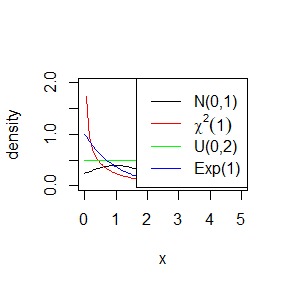

从图中可以看出，$U(0,2)$较为接近$N(1,1)$，而$\chi^2(1)$和$Exp(1)$与$N(1,1)$相差较大。这也与上面的结果相吻合。

# HW4

## Question

1. 在名义水平$\alpha=0.1$下，比较Bonferroni correction和B-H correction的FWER，FDR，TPR，参数设置如下：共1000个假设，950个服从原假设，p值服从$U(0,1)$；50个拒绝原假设，p值服从$Beta(0.1,1)$，重复实验10000次。解释你的结果。

8.4 对于boot包中的aircondit数据集，假设数据来自指数分布$Exp(\lambda)$。求$\lambda$的MLE，并用bootstrap法估计其偏差和标准差。

8.7 对于bootstrap包中的scor数据集，估计其最大主成分占比$\theta=\frac{\lambda_1}{\sum_{j=1}^5 \lambda_j}$，并用bootstrap法估计其偏差和标准差。

## Answer

### 1

```r
set.seed(0)
test <- function(r, r_true){
  t <- table(r, r_true)
  return(list(FWER=t[1,1]>0,
              FDR=t[1,1]/sum(t[1,]),
              TPR=t[1,2]/sum(t[,2])))
}
```

```r
n0 <- 950
n1 <- 50
alpha <- 0.1
m <- 10000
H <- c(rep(0,n0),rep(1,n1))

result <- replicate(m, expr = {
  p <- c(runif(n0), rbeta(n1,0.1,1))
  p_Bonf <- p.adjust(p, method = "bonf")
  r_Bonf <- p_Bonf > alpha
  p_BH <- p.adjust(p, method = "BH")
  r_BH <- p_BH > alpha
  c(unlist(test(r_Bonf,H)), unlist(test(r_BH,H)))
})

matrix(rowMeans(result), nrow = 3,
       dimnames = list(c('FWER', 'FDR', 'TPR'),
       c('Bonferroni correction', 'B-H correction')))
```

```
##      Bonferroni correction B-H correction
## FWER           0.084500000     0.92980000
## FDR            0.004357993     0.09480224
## TPR            0.397778000     0.56121400
```

Bonferroni correction控制FWER低于名义水平$\alpha$，而B-H correction控制FDR低于名义水平$\alpha$，因此二者对应参数都接近名义水平$\alpha=0.1$。Bonferroni correction比B-H correction更为严格，他能更好的保护原假设，FWER和FDR都远低于B-H correction对应值，但也因此降低了功效，表现为TPR低于B-H correction的TPR。因此，Bonferroni correction适合验证性研究，可以提供更强的证据；B-H correction适合探索性研究，更容易发现问题。

### 8.4

$\lambda$的MLE为样本均值的倒数$\hat{\lambda}=\frac{1}{\bar x}$。

```r
data <- boot::aircondit %>% unlist
lambda_hat <- 1/mean(data)
lambda_hat
```

```
## [1] 0.00925212
```

计算可得$\hat{\lambda}=$ 0.00925。

```r
lambda_boot <- replicate(10000, expr = {
  1/mean(sample(data, replace = T))
})
mean(lambda_boot)-lambda_hat # 偏差
```

```
## [1] 0.001324696
```

```r
sd(lambda_boot) # 标准差
```

```
## [1] 0.004249677
```

用Bootstrap法计算估计值的偏差和标准差，偏差为0.00132，标准差为0.0042497。

### 8.7

```r
data <- bootstrap::scor
n <- dim(data)[1]
Cov <- cov(data)
Eig <- eigen(Cov)$values
theta <- Eig[1]/sum(Eig)
```

参数的估计值为0.61912。

```r
theta_boot <- replicate(10000, expr = {
  i <- sample(1:n, replace = T)
  Cov <- cov(data[i,])
  Eig <- eigen(Cov)$values
  Eig[1]/sum(Eig)
})

mean(theta_boot)-theta # 偏差
```

```
## [1] 0.0006990037
```

```r
sd(theta_boot) # 标准差
```

```
## [1] 0.04791316
```

# HW5

## Question

8.8 对于bootstrap包中的scor数据集，估计其最大主成分占比$\theta=\frac{\lambda_1}{\sum_{j=1}^5 \lambda_j}$，并用jackknife法估计其偏差和标准差。

8.11 对于DAAG包中的ironslag数据集，利用leave-two-out cross validation来比较以下四个模型：线性模型，二次模型，指数模型和对数-对数模型。

8.A 利用蒙特卡洛实验来估计standard normal bootstrap confidence interval, basic bootstrap confidence interval和percentile confidence interval的覆盖率。样本总体为正态分布，估计量为样本均值。同时计算真实参数落在区间左侧和区间右侧的比例。

## Answer

### 8.8

```r
set.seed(0)
estimate <- function(data){
  n <- dim(data)[1]
  Cov <- cov(data)
  Eig <- eigen(Cov)$values
  Eig[1]/sum(Eig)
}
```

```r
data <- bootstrap::scor
n <- dim(data)[1]


theta <- estimate(data)
theta_jack <- sapply(1:n, function(i) estimate(data[-i,]))
```

用Jackknife法计算估计值的偏差和标准差，偏差为0.00107，标准差为0.0496。

### 8.11

```r
data <- DAAG::ironslag
n <- dim(data)[1]
index <- gtools::permutations(n,2)

res <- apply(index, MARGIN = 1, FUN = function(i){
    fit1 <- lm(magnetic~chemical, data[-i,])
    fit2 <- lm(magnetic~chemical+I(chemical^2), data[-i,])
    fit3 <- lm(log(magnetic)~chemical, data[-i,])
    fit4 <- lm(log(magnetic)~log(chemical), data[-i,])
    return(c(predict(fit1, newdata=data[i,]) - data[i,'magnetic'],
           predict(fit2, newdata=data[i,]) - data[i,'magnetic'],
           exp(predict(fit3, newdata=data[i,])) - data[i,'magnetic'],
           exp(predict(fit4, newdata=data[i,])) - data[i,'magnetic']))
  })
```

由leave-two-out cross validation得到的预报均方误差分别为19.5723, 17.8702, 18.4549, 20.4672，最优的模型为二次模型，与leave-one-out的结果相同。

### 8.A

样本总体选择$N(0,1)$，样本量分别为20、50、100和200，bootstrap抽样次数为200，名义置信水平为$95\%$，实验重复1000次。

```r
in_interval <- function(theta, interval){
  if(theta<interval[1]){
    return(-1)
  } else if(theta>interval[2]){
    return(1)
  } else return(0)
}
```

```r
# 参数设置
R <- 200
m <- 1000
mu <- 0
```

```r
n <- 20
result1 <- replicate(m, expr = {
  x <- rnorm(n,mu,1)
  x_boot <- boot(x, statistic = function(x,i) mean(x[i]), R=R)
  interval <- boot.ci(x_boot, type = c("norm",'basic','perc'))
  return(c(in_interval(mu,interval$normal[2:3]),
           in_interval(mu,interval$basic[4:5]),
           in_interval(mu,interval$percent[4:5])))
})
n <- 50
result2 <- replicate(m, expr = {
  x <- rnorm(n,mu,1)
  x_boot <- boot(x, statistic = function(x,i) mean(x[i]), R=R)
  interval <- boot.ci(x_boot, type = c("norm",'basic','perc'))
  return(c(in_interval(mu,interval$normal[2:3]),
           in_interval(mu,interval$basic[4:5]),
           in_interval(mu,interval$percent[4:5])))
})
n <- 100
result3 <- replicate(m, expr = {
  x <- rnorm(n,mu,1)
  x_boot <- boot(x, statistic = function(x,i) mean(x[i]), R=R)
  interval <- boot.ci(x_boot, type = c("norm",'basic','perc'))
  return(c(in_interval(mu,interval$normal[2:3]),
           in_interval(mu,interval$basic[4:5]),
           in_interval(mu,interval$percent[4:5])))
})
n <- 200
result4 <- replicate(m, expr = {
  x <- rnorm(n,mu,1)
  x_boot <- boot(x, statistic = function(x,i) mean(x[i]), R=R)
  interval <- boot.ci(x_boot, type = c("norm",'basic','perc'))
  return(c(in_interval(mu,interval$normal[2:3]),
           in_interval(mu,interval$basic[4:5]),
           in_interval(mu,interval$percent[4:5])))
})

# n=20的结果（-1代表落在区间左侧，0代表落在区间内，1代表落在区间右侧）
(apply(result1,1, table)/m) %>% `colnames<-`(.,c("norm",'basic','perc'))
```

```
##     norm basic  perc
## -1 0.042 0.043 0.042
## 0  0.928 0.929 0.923
## 1  0.030 0.028 0.035
```

```r
# n=50的结果
(apply(result2,1, table)/m) %>% `colnames<-`(.,c("norm",'basic','perc'))
```

```
##     norm basic  perc
## -1 0.026 0.023 0.023
## 0  0.945 0.955 0.948
## 1  0.029 0.022 0.029
```

```r
# n=100的结果
(apply(result3,1, table)/m) %>% `colnames<-`(.,c("norm",'basic','perc'))
```

```
##     norm basic  perc
## -1 0.025 0.023 0.026
## 0  0.959 0.958 0.959
## 1  0.016 0.019 0.015
```

```r
# n=200的结果
(apply(result4,1, table)/m) %>% `colnames<-`(.,c("norm",'basic','perc'))
```

```
##     norm basic  perc
## -1 0.038 0.037 0.030
## 0  0.933 0.937 0.938
## 1  0.029 0.026 0.032
```

### 1

```r
# 参数设置
lambda <- 2
R <- 1000
m <- 1000
```

```r
n <- 5
bias_n <- lambda/(n-1)
sd_n <- lambda*n/(n-1)/sqrt(n-2)
result1 <- replicate(m, expr = {
  x <- rexp(n, rate = lambda)
  x_boot <- boot(x,statistic = function(x,i) 1/mean(x[i]),R=R,parallel = 'multicore')$t
  return(c(mean(x_boot)-1/mean(x), sd(x_boot)))
})
# n=5
data.frame(true=c(bias_n,sd_n),bootstrap=rowMeans(result1),
           row.names = c('bias','sd'))
```

```
##          true bootstrap
## bias 0.500000 0.5997541
## sd   1.443376 2.2638870
```

```r
n <- 10
bias_n <- lambda/(n-1)
sd_n <- lambda*n/(n-1)/sqrt(n-2)
result2 <- replicate(m, expr = {
  x <- rexp(n, rate = lambda)
  x_boot <- boot(x,statistic = function(x,i) 1/mean(x[i]),R=R,parallel = 'multicore')$t
  return(c(mean(x_boot)-1/mean(x), sd(x_boot)))
})
# n=10
data.frame(true=c(bias_n,sd_n),bootstrap=rowMeans(result2),
           row.names = c('bias','sd'))
```

```
##           true bootstrap
## bias 0.2222222 0.2204153
## sd   0.7856742 0.8287096
```

```r
n <- 20
bias_n <- lambda/(n-1)
sd_n <- lambda*n/(n-1)/sqrt(n-2)
result3 <- replicate(m, expr = {
  x <- rexp(n, rate = lambda)
  x_boot <- boot(x,statistic = function(x,i) 1/mean(x[i]),R=R,parallel = 'multicore')$t
  return(c(mean(x_boot)-1/mean(x), sd(x_boot)))
})
# n=20
data.frame(true=c(bias_n,sd_n),bootstrap=rowMeans(result3),
           row.names = c('bias','sd'))
```

```
##           true bootstrap
## bias 0.1052632 0.1040668
## sd   0.4962153 0.5034564
```

结果如上。从中可以看出，随着样本量的增加，bootstrap估计的偏差和标准差逐渐接近真实的偏差和标准差，且标准差的收敛速度要慢于偏差。

# HW6

## Question

10.3 完成基于置换检验的两样本Cramér-von Mises检验并应用于例10.1和例10.2的数据上。

10.7 基于端点个数最大值，构造一个等方差置换检验，使之适用于样本量不同的情况。使用该检验重复例7.15。

1 证明连续情形下M-H抽样器的平稳分布也是目标分布。

## Answer

### 10.3

先完成Cramér-von Mises检验统计量的计算。

```r
set.seed(0)
CM <- function(x,y){
  x <- sort(x)
  y <- sort(y)
  n <- length(x)
  m <- length(y)
  r <- rank(c(x,y))
  rx <- r[1:n]
  ry <- r[-(1:n)]
  U <- n*sum((rx-1:n)^2)+m*sum((ry-1:m)^2)
  W <- U/n/m/(n+m)-(4*m*n-1)/6/(n+m)
  return(W)
}

CM.boot <- function(z,ix,nx){
  z <- z[ix]
  CM(z[1:nx],z[-(1:nx)])
}
```

将Cramér-von Mises检验应用于例10.1的数据。

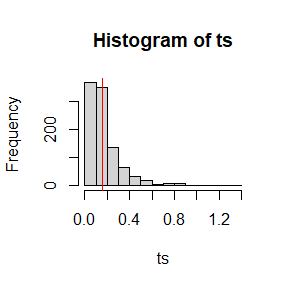

```r
attach(chickwts)
x <- sort(weight[feed == "soybean"])
y <- sort(weight[feed == "linseed"])
detach(chickwts)

boot.obj <- boot(data = c(x,y), statistic = CM.boot, R=999,
                 sim = "permutation", nx=length(x))
ts <- c(boot.obj$t0,boot.obj$t)
p.value <- mean(ts>=ts[1])
hist(ts)
abline(v=ts[1], col='red')
```

置换检验所得的Cramér-von Mises检验统计量的分布如上图，检验的p值为0.391，没有充足的证据拒绝原假设，即认为两个样本同分布。

### 10.7

记$k_i$为第i个样本的端点个数（i=1,2），检验统计量取为$K=\underset{i}\max k_i$，拒绝域形如$\{K\geq K_0\}$，p值为$p=P(K^*\geq K)$，其中$K^*$为置换得到的样本的检验统计量。代码实现如下：

```r
K <- function(x, y) {
 X <- x- mean(x)
 Y <- y- mean(y)
 outx <- sum(X > max(Y)) + sum(X < min(Y))
 outy <- sum(Y > max(X)) + sum(Y < min(X))
 return(as.integer(max(c(outx, outy))))
 }

K.boot <- function(z, ix, nx){
  z <- z[ix]
  return(K(z[1:nx],z[-(1:nx)]))
}

K.test <- function(x,y,...){
  boot.obj <- boot(data = c(x,y), statistic = K.boot,...,
                 sim = "permutation", nx=length(x))
  ts <- c(boot.obj$t0,boot.obj$t)
  mean(ts>=ts[1])
}
```

重复例7.15的蒙特卡洛实验。

```r
n1 <- 20
n2 <- 30
mu1 <- mu2 <- 0
sigma1 <- sigma2 <- 1
m <- 10000

sfInit(parallel = T,cpus = 8)
```

```
## snowfall 1.84-6.3 initialized (using snow 0.4-4): parallel execution on 8 CPUs.
```

```r
sfExportAll()
sfLibrary(boot)
```

```
## Library boot loaded.
```

```
## Library boot loaded in cluster.
```

```r
ps1 <- sfSapply(1:m, fun = function(k){
  x <- rnorm(n1, mu1, sigma1)
  y <- rnorm(n2, mu2, sigma2)
  x <- x- mean(x) #centered by sample mean
  y <- y- mean(y)
  K.test(x, y, R=999)
})
sfStop()
```

```
##
## Stopping cluster
```

```r
n1 <- 20
n2 <- 50
mu1 <- mu2 <- 0
sigma1 <- sigma2 <- 1
m <- 10000

sfInit(parallel = T,cpus = 8)
```

```
## snowfall 1.84-6.3 initialized (using snow 0.4-4): parallel execution on 8 CPUs.
```

```r
sfExportAll()
sfLibrary(boot)
```

```
## Library boot loaded.
```

```
## Library boot loaded in cluster.
```

```r
ps2 <- sfSapply(1:m, fun = function(k){
  x <- rnorm(n1, mu1, sigma1)
  y <- rnorm(n2, mu2, sigma2)
  x <- x- mean(x) #centered by sample mean
  y <- y- mean(y)
  K.test(x, y, R=999)
})
sfStop()
```

```
##
## Stopping cluster
```

当$n_1=20$，$n_2=30$时，取名义第一类错误率$\alpha=0.05$，经验第一类错误率为0.0359。$n_1=20$，$n_2=50$时重复实验，经验第一类错误率为0.0405。可以看到，该检验略为保守，但在样本量相差较大时依然稳健。

### 1

任取状态空间中的两个点(r,s)，则转移核为
$$K(r,s)=I(r\neq s)g(s|r)\alpha(r,s)+I(r=s)(1-\int g(s|r)\alpha(r,s)ds)$$

下面验证$K(r,s)f(r)=K(s,r)f(s)$。

$r=s$时，显然成立。

$r\neq s$时，不妨设$f(s)g(r|s)\geq f(r)g(s|r)$，则$\alpha(r,s)=1$，$\alpha(s,r)=\frac{f(r)g(s|r)}{f(s)g(r|s)}$。因此
$$K(s,r)f(s)=g(r|s)\alpha(s,r)f(s)=g(r|s)\frac{f(r)g(s|r)}{f(s)g(r|s)}f(s)=f(r)g(s|r)=K(r,s)f(r).$$

可以验证平稳性条件
$$\int K(r,s)f(r)dr=\int K(s,r)f(s)dr=f(s)$$

因此M-H抽样器的平稳分布为f。

# HW7

## Question

11.6 实现一个随机游走Metropolis采样器以生成标准拉普拉斯分布。比较不同方差生成的链并计算接受率。

11.10 对于如下的密度函数
$$f(x,y)\propto \binom{n}{x}y^{x+a-1}(1-y)^{n-x+b-1},$$
注意到
$$X|Y=y\sim B(n,y) \quad Y|X=x\sim Beta(x+a,n-x+b).$$

用Gibbs采样法生成来自上述密度函数的链。

1 对于前两道题，用Gelman-Rubin法监测链的收敛性，生成链直到它大致收敛到目标分布，即$\hat R<1.2$。

2 考虑模型
$$P(Y=1|X_1,x_2,X_3)=\frac{1}{1+exp\{-(\alpha+b_1X_1+b_2X_2+b_3X_3)\}},$$
其中$X_1\sim Poi(1)$，$X_2\sim Exp(1)$，$X_3\sim B(1,0.5)$。

（1）写一个R函数实现slide P11的功能，其输入值为N，$b_1$，$b_2$，$b_3$，$f_0$，输出值为$\alpha$。 （2）调用该函数，输入值为$N=10^6$，$b_1=1$，$b_2=2$，$b_3=-1$，$f_0=0.1,0.01,0.001,0.0001$。 （3）画$-\log{f_0}$vs$\alpha$散点图。

## Answer

### 11.6

```r
set.seed(0)
RandomWalkMCMC <- function(N, sigma2, X1=NULL){
  x <- numeric(N)
  r <- numeric(N)
  sigma <- sqrt(sigma2)
  if(is.null(X1)){
    x[1] <- rnorm(1,0,sigma)
  } else {
    x[1] <- X1
  }

  r[1] <- T
  for(i in 2:N){
    y <- rnorm(1, x[i-1], sigma)
    u <- runif(1)
    #a <- exp(abs(x[i-1])-abs(y))
    a <- dnorm(y,0,1)/dnorm(x[i-1],0,1)
    r[i] <- u<a
    x[i] <- r[i]*y + (1-r[i])*x[i-1]
  }
  return(list(x=x, acceptance=r))
}
```

提议分布的方差分别取为$\sigma^2=0.1,0.5,2,16$，链条长度为$N=5000$，比较不同方差下生成的链及其接受率。

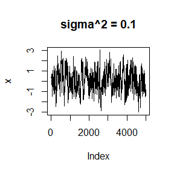

```r
N <- 5000
rst1 <- RandomWalkMCMC(N=N, sigma2 = 0.1)
rst2 <- RandomWalkMCMC(N=N, sigma2 = 0.5)
rst3 <- RandomWalkMCMC(N=N, sigma2 = 2)
rst4 <- RandomWalkMCMC(N=N, sigma2 = 16)


plot(rst1$x, main = 'sigma^2 = 0.1',type = 'l',ylab = 'x')
```

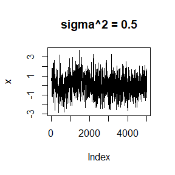

```r
plot(rst2$x, main = 'sigma^2 = 0.5',type = 'l',ylab = 'x')
```

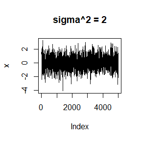

```r
plot(rst3$x, main = 'sigma^2 = 2',type = 'l',ylab = 'x')
```

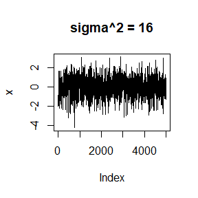

```r
plot(rst4$x, main = 'sigma^2 = 16',type = 'l',ylab = 'x')
```

```r
# 接受率
c(mean(rst1$acceptance),mean(rst2$acceptance),
  mean(rst3$acceptance),mean(rst4$acceptance))
```

```
## [1] 0.9054 0.7874 0.6026 0.2938
```

上图为不同方差下生成的链条的曲线图，可以看到在方差很小时，链收敛得很慢；在方差很大时，链收敛得很快，但同时接受率很低；在方差大小适中时，链的收敛速度和接受率都较好。四条链的接受率分别为0.905, 0.787, 0.603, 0.294。方差为0.1时，绝大部分的样本都被接受了，而方差为16时，大部分的样本都被拒绝了。

### 11.10

取参数为$a=1$，$b=2$，$n=15$，链条长度为$N=3000$，X的初始值取为1，用Gibbs采样法生成对应的链。

```r
N <- 3000
a <- 1
b <- 2
n <- 15
x <- numeric(N)
y <- numeric(N)
x[1] <- 1

for(i in 1:N){
  y[i] <- rbeta(1,x[i]+a,n-x[i]+b)
  x[i+1] <- rbinom(1,n,y[i])
}
x <- x[1:N]
```

### 1

以均值作为汇总统计量，计算11.6对应的Gelman-Rubin统计量。对于不同的标准差，分别生成四条初值不同的链条，初值取为$-10,-5,5,10$。

```r
Gelman.Rubin <- function(psi) {
  # psi[i,j] is the statistic psi(X[i,1:j])
  # for chain in i-th row of X
  psi <- as.matrix(psi)
  n <- ncol(psi)
  k <- nrow(psi)
  psi.means <- rowMeans(psi)
  B <- n * var(psi.means)
  #row means
  #between variance est.
  psi.w <- apply(psi, 1, "var") #within variances
  W <- mean(psi.w)
  #within est.
  v.hat <- W*(n-1)/n + (B/n)
  r.hat <- v.hat / W
  return(r.hat)
 }
```

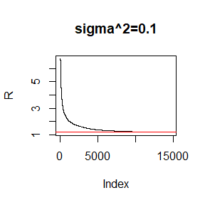

```r
b <- 200 # burn-in

plot(R1[-(1:b)],type='l',ylab='R',
     main = 'sigma^2=0.1')
abline(h=1.2, col='red')
```

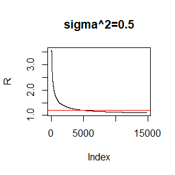

```r
plot(R2[-(1:b)],type='l',ylab='R',
     main = 'sigma^2=0.5')
abline(h=1.2, col='red')
```

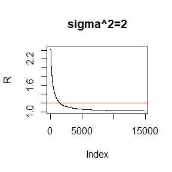

```r
plot(R3[-(1:b)],type='l',ylab='R',
     main = 'sigma^2=2')
abline(h=1.2, col='red')
```

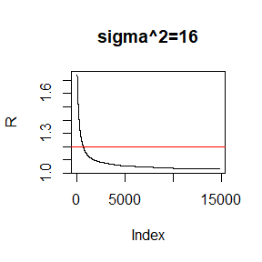

```r
plot(R4[-(1:b)],type='l',ylab='R',
     main = 'sigma^2=16')
abline(h=1.2, col='red')
```

上图为不同方差下Gelman-Rubin统计量的情况（不包含前200个值），可以看到随着方差的增大，收敛速度也随之加快。下图为对应四条链的均值（不包含前200个值），黑色竖线代表$R<1.2$时的指标。可以看到此时四条链的统计指标较为接近。

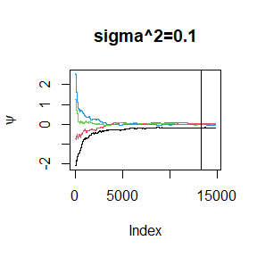

```r
plot(psi1[1,-(1:b)],type = "l", ylab=bquote(psi),
     ylim=c(min(psi1[,-(1:b)]),max(psi1[,-(1:b)])),
     main = 'sigma^2=0.1')
lines(psi1[2,-(1:b)],col=2)
lines(psi1[3,-(1:b)],col=3)
lines(psi1[4,-(1:b)],col=4)
abline(v=min(which(R1[-(1:b)]<1.2)),lwd=1.5)
```

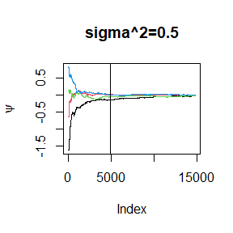

```r
plot(psi2[1,-(1:b)],type = "l", ylab=bquote(psi),
     ylim=c(min(psi2[,-(1:b)]),max(psi2[,-(1:b)])),
     main = 'sigma^2=0.5')
lines(psi2[2,-(1:b)],col=2)
lines(psi2[3,-(1:b)],col=3)
lines(psi2[4,-(1:b)],col=4)
abline(v=min(which(R2[-(1:b)]<1.2)),lwd=1.5)
```

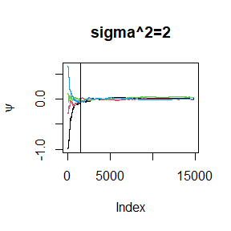

```r
plot(psi3[1,-(1:b)],type = "l", ylab=bquote(psi),
     ylim=c(min(psi3[,-(1:b)]),max(psi3[,-(1:b)])),
     main = 'sigma^2=2')
lines(psi3[2,-(1:b)],col=2)
lines(psi3[3,-(1:b)],col=3)
lines(psi3[4,-(1:b)],col=4)
abline(v=min(which(R3[-(1:b)]<1.2)),lwd=1.5)
```

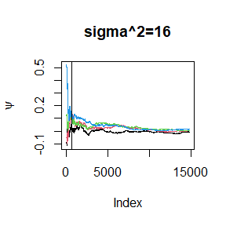

```r
plot(psi4[1,-(1:b)],type = "l", ylab=bquote(psi),
     ylim=c(min(psi4[,-(1:b)]),max(psi4[,-(1:b)])),
     main = 'sigma^2=16')
lines(psi4[2,-(1:b)],col=2)
lines(psi4[3,-(1:b)],col=3)
lines(psi4[4,-(1:b)],col=4)
abline(v=min(which(R4[-(1:b)]<1.2)),lwd=1.5)
```

以均值作为汇总统计量，计算11.10对应的Gelman-Rubin统计量。参数取为$a=1$，$b=2$，$n=15$，链条长度为$N=3000$。生成三条链，X的初值分别取为$0,8,15$。

```r
Gibbs <- function(N,a,b,n,X1){
  x <- numeric(N)
  y <- numeric(N)
  x[1] <- X1

  for(i in 1:N){
    y[i] <- rbeta(1,x[i]+a,n-x[i]+b)
    x[i+1] <- rbinom(1,n,y[i])
  }
  x <- x[1:N]
  return(data.frame(x=x,y=y))
}
```

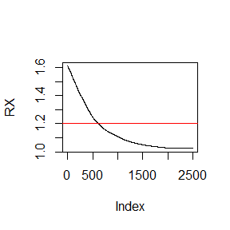

```r
b <- 500

plot(RX[-(1:b)],type = 'l',ylab = 'RX')
abline(h=1.2,col='red')
```

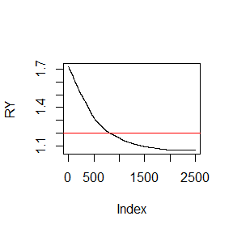

```r
plot(RY[-(1:b)],type = 'l',ylab='RY')
abline(h=1.2,col='red')
```

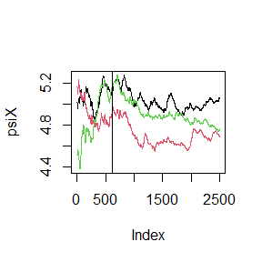

```r
plot(psiX[1,-(1:b)],type = "l", ylab='psiX',
     ylim=c(min(psiX[,-(1:b)]),max(psiX[,-(1:b)])))
lines(psiX[2,-(1:b)],col=2)
lines(psiX[3,-(1:b)],col=3)
abline(v=min(which(RX[-(1:b)]<1.2)),lwd=1.5)
```

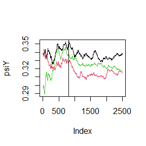

```r
plot(psiY[1,-(1:b)],type = "l", ylab='psiY',
     ylim=c(min(psiY[,-(1:b)]),max(psiY[,-(1:b)])))
lines(psiY[2,-(1:b)],col=2)
lines(psiY[3,-(1:b)],col=3)
abline(v=min(which(RY[-(1:b)]<1.2)),lwd=1.5)
```

上图为11.10的Gelman-Rubin统计量和对应的均值（不包含前500个值），黑色竖线代表$R<1.2$时的指标。可以看到此时三条链的统计指标较为接近。

### 2

#### （1）

题中要求的R函数如下：

```r
estimate <- function(N,b1,b2,b3,f0){
    x1 <- rpois(N,1)
    x2 <- rexp(N,1)
    x3 <- rbinom(N,1,0.5)
    uniroot(f = function(alpha){
        r <- rbinom(N,1,prob = 1/(1+exp(-(alpha+b1*x1+b2*x2+b3*x3))))
        mean(r)-f0
    }, interval = c(-30,0))$root

}
```

#### （2）

结果如下

```r
N <- 1e6
b1 <- b2 <- 1
b3 <- -1

alpha <- c(estimate(N,b1,b2,b3,f0 = 0.1),
estimate(N,b1,b2,b3,f0 = 0.01),
estimate(N,b1,b2,b3,f0 = 0.001),
estimate(N,b1,b2,b3,f0 = 0.0001))

alpha
```

```
## [1]  -4.492715  -7.590907 -10.300136 -12.892157
```

#### （3）

散点图如下：

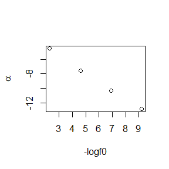

```r
plot(-log(c(.1,.01,.001,.0001)),alpha,
     xlab = '-logf0',ylab = bquote(alpha))
```

可以看到二者近似呈线性关系。

# HW8

## Question

11.4 证明几何分布具有无记忆性。

14.1 用单纯性法解如下线性规划问题：
$$\begin{aligned}
\min & \; 4x+2y+9z \\
\text{subject to }& 2x+y+z\leq 2 \\
& x-y+3z\leq 3 \\
& x,y,z\geq 0
\end{aligned}$$

1 设$X_1.\dots,X_n \overset{iid}{\sim}Exp(\lambda)$，因为某种原因，只知道$X_i$落在区间$(u_i,v_i)$上，其中$u_i,v_i$非随机。

1. 试分别直接极大化观测数据的似然函数和采用EM算法求解$\lambda$的MLE。证明EM算法收敛于观测数据的MLE，且收敛具有线性速度。
2. 设$(u_i,v_i),\quad i=1,\dots,10$的观测数据为(11,12),(8,9),(27,28),(13,14),(16,17),(0,1),(23,24),(10,11),(24,25),(2,3)。试分别编程实现上述两种算法并比较结果。
3. 数值比较两种算法的收敛速度。

## Answer

### 11.4

由于
$$P(T=l|T\geq k)
=\frac{P(T=l,T\geq k)}{P(T\geq k)}
=\frac{p^l(1-p)I(l\geq k)}{1-\sum_{i=0}^{k-1}p^i(1-p)}
=p^{l-k}(1-p)I(l\geq k)$$

当$l\geq k$时，有$P(T=l|T\geq k)=P(T=l-k)$。

因此几何分布具有无记忆性，特别地，$E[T|T\geq k]=E[T]+k=\frac{p}{1-p}+k$。

### 14.1

```r
set.seed(0)
obj <- c(4,2,9)
c.mat <- rbind(matrix(c(2,1,1,-1,1,3),nrow = 2),
               diag(1,3,3))
c.dir <- c(rep('<=',2), rep('>=',3))
c.rhs <- c(2,3,0,0,0)

result <- lp('min',obj, c.mat,c.dir,c.rhs)
# 最小值
result$objval
```

```
## [1] 0
```

```r
# x,y,z的取值
result$solution
```

```
## [1] 0 0 0
```

最小值为0，在$x=y=z=0$时取得。

### 1

#### (1)

记观测数据为$A_i$={$X_i\in (u_i,v_i)$}，完整数据为$X_i$。则观测数据对数似然函数为
$$l_o(\lambda|A)=\sum_{i=1}^n \log{[e^{-\lambda u_i}-e^{-\lambda v_i}]},$$
完整数据对数似然函数为
$$l_c(\lambda|X,A)=n\log{\lambda}-\lambda \sum_{i=1}^n X_i.$$

E-step:

$$\begin{aligned}
E_{\lambda_0}[l_c(\lambda)|A]
&=n\log{\lambda}-\lambda \sum_{i=1}^n E_{\lambda_0}[X_i|A] \\
&=n\log{\lambda}-\lambda \sum_{i=1}^n
\frac{(u_i+\frac{1}{\lambda_0})e^{-\lambda_0u_i}-(v_i+\frac{1}{\lambda_0})e^{-\lambda_0v_i}}{e^{-\lambda_0u_i}-e^{-\lambda_0v_i}}
\\
&=
n\log{\lambda}-\lambda(\frac{n}{\lambda_0}-l_o^{'}(\lambda_0)) \\
\end{aligned}$$

Q-step:

$\lambda_{1}=\frac{n}{\frac{n}{\lambda_0}-l_o^{'}(\lambda_0)}$。

记
$$f(x)=\frac{n}{\frac{n}{x}-l_o^{'}(x)}=\frac{nx}{n-xl_o^{'}(x)},
\quad x>0.$$

则
$$f^{'}(x)=\frac{1+\frac{1}{n}x^2l_o^{''}(x)}{(1-\frac{1}{n}xl_o^{'}(x))^2}.$$

由于
$$\begin{aligned}
& l^{''}_o(x)=-\sum_{i=1}^n
\frac{(v_i-u_i)^2e^{(v_i-u_i)x}}{(e^{(v_i-u_i)x}-1)^2}<0 \\
&
\end{aligned}$$

因此$l_o$为凹函数，有唯一的极大值点。

记$\lambda^{*}$为$\lambda$的MLE，则$f(\lambda^{*})=\frac{n}{\frac{n}{\lambda^{*}}-l_o^{'}(\lambda^{*})}=\lambda^{*}$，即$\lambda^{*}$为f的不动点。

#### (2)

```r
u <- c(11,8,27,13,16,0,23,10,24,2)
v <- u+1
n <- length(u)
likelihood_o <- function(lambda){
  sum(log(exp(-lambda*u)-exp(-lambda*v)))
}
dlo <- function(lambda){
  sum( (v*exp(-lambda*v)-u*exp(-lambda*u))/(exp(-lambda*u)-exp(-lambda*v)) )
}
ddlo <- function(lambda){
  -sum((u-v)^2*exp(-(u+v)*lambda)/(exp(-u*lambda)-exp(-v*lambda))^2)
}
```

Newton-Raphson 算法：

初始值取为$\lambda_0=10$，停止准则为$|\lambda_{t}-\lambda_{t-1}|\leq10^{-8}$。由于有不等式约束$\lambda\geq0$，故采取回溯直线法调整步长。

```r
lambda_old  <- 0
lambda_new <- 10
iter <- 0
max_iter <- 200
ts <- NULL
lambda_NT <- numeric(max_iter)
while (abs((lambda_old-lambda_new))>1e-8 && iter<max_iter) {
    lambda_old <- lambda_new
    lambda_NT[iter+1] <- lambda_new
    t <- 1
    delta <- dlo(lambda_new)/ddlo(lambda_new)
    while(lambda_new-t*dlo(lambda_new)/ddlo(lambda_new)<0) t <- t/2
    lambda_new <- lambda_new-t*dlo(lambda_new)/ddlo(lambda_new)
    iter <- iter+1
    ts <- c(ts,t)
}
lambda_NT <- lambda_NT[1:iter]
lambda_new
```

```
## [1] 0.0719735
```

最终结果为0.0719735 ，迭代次数为11。

EM算法：

初始值取为$\lambda_0=10$，停止准则为$|\lambda_{t}-\lambda_{t-1}|\leq10^{-8}$。

```r
lambda_old  <- 0
lambda_new <- 10
iter <- 0
max_iter <- 200
lambda_EM <- numeric(max_iter)
while (abs((lambda_old-lambda_new))>1e-8 && iter<max_iter) {
  lambda_old <- lambda_new
  lambda_EM[iter+1] <- lambda_new
  lambda_new <- n/(n/lambda_new-dlo(lambda_new))
  iter <- iter+1
}
lambda_EM <- lambda_EM[1:iter]
lambda_new
```

```
## [1] 0.0719735
```

最终结果为0.0719735 ，迭代次数为4。可以看到EM算法和Newton-Raphson算法收敛到同一个值。

#### (3)

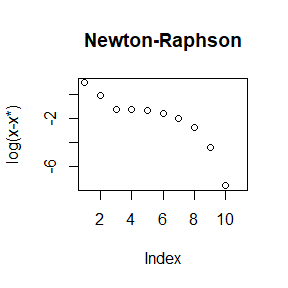

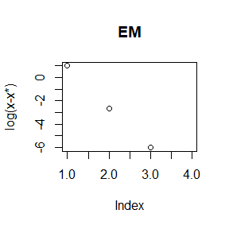

# HW9

## Question

EX6 利用Map()和vapply()来实现lapply()的一个变种。它可以并行运算于输入并返回一个向量或矩阵。

EX4 构建一个更快速的chisq.test()版本，当输入是两个没有缺失值的数值向量时，只计算卡方检验统计量。

EX5 构建一个更快速的table()版本用于输入是两个没有缺失值的数值向量时。用其加速前面的chisq.test()。

## Answer

### EX6

lapply()的变种如下：

```r
set.seed(0)
lapply2 <- function(x, f, ...){
  m <- length(x)
  n <- x[[1]] %>% unlist %>% f %>% length
  unlist(Map(function(z) vapply(z, f, rep(0,n), ...)
             , x)) %>% structure('dim'=c(n,m))
}
```

### EX4

新的chisq.test()如下：

```r
chisq.test2 <- function(x,y){
  A <- table(x,y) %>% as.matrix
  n <- sum(A)
  nc <- ncol(A)
  nr <- nrow(A)
  Ac <- matrix(rep(colSums(A),each=nr),nr,nc)
  Ar <- matrix(rep(rowSums(A),nc),nr,nc)
  n*(sum(A*A/Ac/Ar)-1)
}
```

### EX5

新的table()如下：

```r
table2 <- function(x,y){
  x0 <- unique(x) %>% sort
  y0 <- unique(y) %>% sort
  T <- sapply(y0, function(Y){
    tmp <- x[y==Y]
    vapply(x0, function(X){
        sum(tmp==X)
    },FUN.VALUE = 0L)
})
  class(T) <- 'table'
  T
}
```

用其加速chisq.test()：

```r
chisq.test3 <- function(x,y){
  A <- table2(x,y) %>% as.matrix
  n <- sum(A)
  nc <- ncol(A)
  nr <- nrow(A)
  Ac <- matrix(rep(colSums(A),each=nr),nr,nc)
  Ar <- matrix(rep(rowSums(A),nc),nr,nc)
  n*(sum(A*A/Ac/Ar)-1)
}
```

# HW10

## Question

11.8 用Rcpp实现以下功能：
$$X|\theta\sim
MB(\frac{1}{2}+\frac{\theta}{4},\frac{1-\theta}{4},\frac{1-\theta}{4},\frac{\theta}{4}),$$
X的观测值为(125,18,20,34)。用MCMC方法估计$\theta$的后验分布。

1 用qqplot比较R函数生成的随机数和前述函数生成的随机数。

2 用microbenchmark函数比较两个函数的用时。

3 评价你的结果。

## Answer

### 11.8

用Cpp实现以上功能。

```r
set.seed(0)
cppFunction('
NumericVector MCMCC(int N) {
  auto f = [](double x) -> double {
        return pow(2+x, 125) * pow(1-x, 38) * pow(x, 34) * (x > 0) * (x < 1);
    };
    NumericVector X(N);
    X[0] = 0.6;
    double u = 0,y = 0;
    for(int i = 1; i < N; i++) {
    y = rnorm(1,X[i-1],pow(0.5,2))[0];
        u = runif(1)[0];
        X[i]=((u<f(y)/f(X[i-1]))?y:X[i-1]);
    }
    return(X);
}')
```

用R实现相同功能。

```r
f <- function(x){
  (2+x)^125*(1-x)^38*x^34*(x<1)*(x>0)/2.357695e+28
}

MCMCR <- function(N){
  X <- numeric(N)
  X[1] <- 0.6
  u <- runif(N)
  for(i in 2:N){
    y <- rnorm(1,X[i-1],0.5^2)
    if(u[i]<f(y)/f(X[i-1])){
      X[i] <- y
    } else X[i] <- X[i-1]
  }
  X
}
```

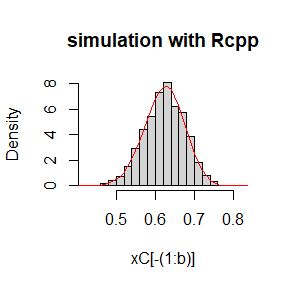

```r
N <- 20000
b <- 7000

xC <- MCMCC(N)
hist(xC[-(1:b)], freq = F,
     main = 'simulation with Rcpp')
lines(seq(0,1,0.01),f(seq(0,1,0.01)),col='red')
```

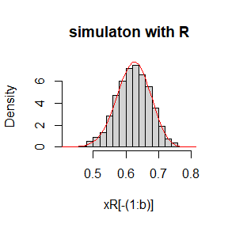

```r
xR <- MCMCR(N)
hist(xR[-(1:b)], freq = F,
     main = 'simulaton with R')
lines(seq(0,1,0.01),f(seq(0,1,0.01)),col='red')
```

### 1

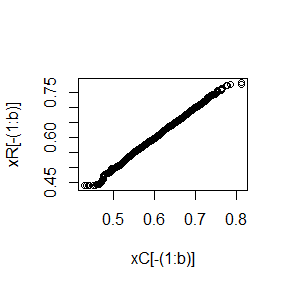

```r
qqplot(xC[-(1:b)],xR[-(1:b)])
```

从Q-Q图中可以看出，在(0.5,0.75)这段密度较高的区域，两种方法生成的随机数的分位数近似相同；但在两端低密度区域，由于生成的样本点很少，受随机性的影响，两种方法的分位数不太吻合。

### 2

```r
microbenchmark(MCMCC(N),MCMCR(N))
```

```
## Unit: milliseconds
##      expr     min       lq     mean   median       uq     max neval
##  MCMCC(N)  2.9256  2.99890  3.26151  3.04210  3.14535  4.6101   100
##  MCMCR(N) 31.9158 33.59025 34.25912 33.79365 33.97505 80.7761   100
```

可以看到，使用Cpp用时仅为使用R的不到十分之一，它极大地加快了运算速度。